# New Users - Channel

Shyni David

11/25/2019

Loading packages

```r
library(openxlsx)
library(tidyverse)
```

```r
library(readxl)
library(ggplot2)
#install.packages("nnet")
library(nnet) # for multinomial logit
```

Import Data Channel-New Users

```r
DA <-  read_excel("~/Desktop/Job related/Surefoot/Surefoot 2/Surefoot- GA/Analysis - 2/test and control dates/New Users + Channel/New Users+Channel.xlsx", sheet = 2)
```

Data wrangling

```r
DA_01 <- DA

colnames(DA_01)[colnames(DA_01)=="Default Channel Grouping"] <- "Channel"
colnames(DA_01)[colnames(DA_01)=="Date Range"] <- "Date_Range"
colnames(DA_01)[colnames(DA_01)=="New Users"] <- "New_Users"
colnames(DA_01)[colnames(DA_01)=="Bounce Rate"] <- "Bounce_Rate"


DA_02 <- DA_01 %>% filter(!is.na(Channel))

DA_03 <- DA_02 %>% mutate(test_categ = ifelse(Date_Range == "Oct 18, 2019 - Oct 31, 2019", "test-Oct 18,2019 - Oct 31,2019", "control-Oct 4,2019 - Oct 17,2019"))

DN_m <- DA_03 %>% filter(Date_Range == "Oct 18, 2019 - Oct 31, 2019")
```

Visualization Channel-New Users count

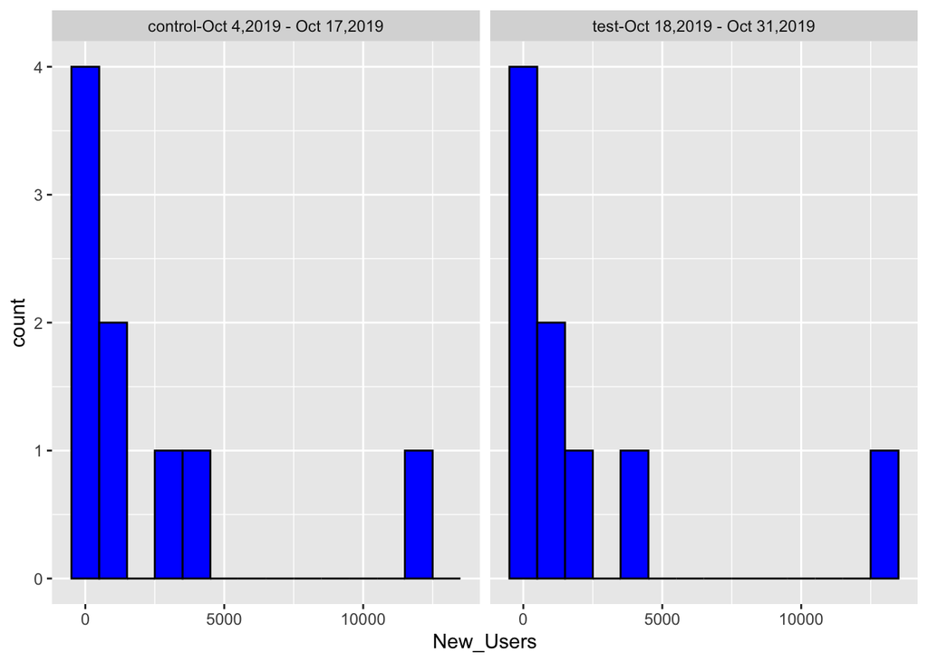

```r
DA_03 %>% filter(Users > 0 ) %>% ggplot() + geom_histogram(aes(New_Users), binwidth = 1000, fill = "blue",col = "black") + facet_wrap(~test_categ)
```

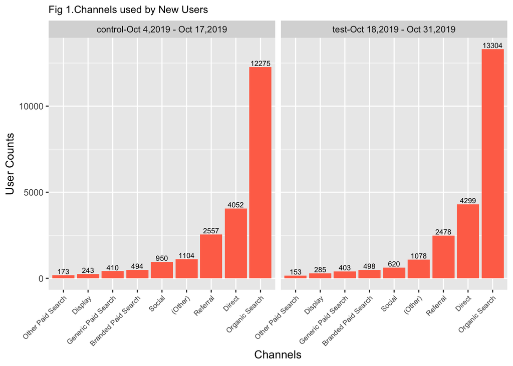

```r
DA_03 %>%
  group_by(Channel) %>%
  ggplot(aes(reorder(x =  as.factor(Channel), New_Users),  y=New_Users)) + geom_bar(stat = 'identity', fill = "coral1") + ggtitle("Fig 1.Channels used by New Users") + geom_text(aes(label=New_Users), size = 2.5, position=position_dodge(width=0.2), vjust=-0.25) + theme(plot.title = element_text(size =10),axis.text.x = element_text(size =7,angle = 45, hjust = 1))  + xlab("Channels") +ylab("User Counts")+ facet_wrap(~test_categ)
```

Channel-New Users-Sessions

[figure not shown]

```r
DA_03 %>%
  group_by(Channel) %>%
  ggplot(aes(reorder(x =  as.factor(Channel), Sessions),  y=Sessions)) + geom_bar(stat = 'identity', fill = "coral1") + ggtitle("Fig. 2 Sessions in Channels used by New Users") + geom_text(aes(label=Sessions), size = 2.5, position=position_dodge(width=0.2), vjust=-0.25) + theme(plot.title = element_text(size =10),axis.text.x = element_text(size =7,angle = 45, hjust = 1))  + xlab("Channels") +ylab("Sessions")+ facet_wrap(~test_categ)
```

Channel-New Users-Bounce Rate

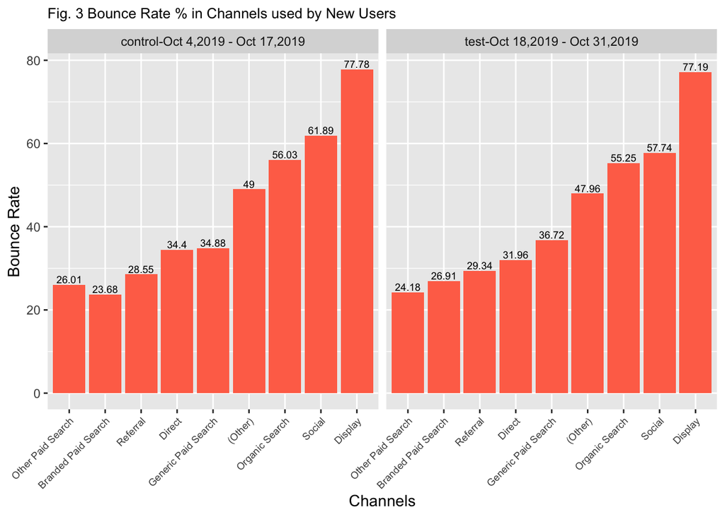

```r
DA_03_01 <- DA_03 %>% mutate(Bounce_Rt = round(Bounce_Rate*100,2))
DA_03_01 %>%
  group_by(Channel) %>%
  ggplot(aes(reorder(x =  as.factor(Channel), Bounce_Rt),  y=Bounce_Rt)) + geom_bar(stat = 'identity', fill = "coral1") + ggtitle("Fig. 3 Bounce Rate % in Channels used by New Users") + geom_text(aes(label=Bounce_Rt), size = 2.5, position=position_dodge(width=0.2), vjust=-0.25) + theme(plot.title = element_text(size =10),axis.text.x = element_text(size =7,angle = 45, hjust = 1))  + xlab("Channels") +ylab("Bounce Rate")+ facet_wrap(~test_categ)
```

Channel-New Users-Revenue

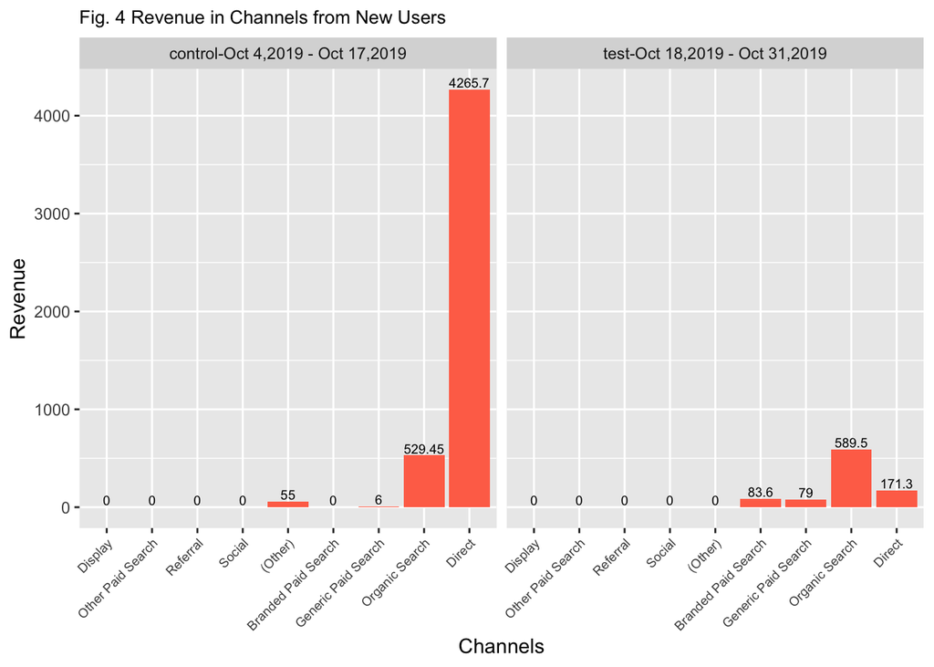

```r
DA_03 %>%
  group_by(Channel) %>%
  ggplot(aes(reorder(x =  as.factor(Channel), Revenue),  y=Revenue)) + geom_bar(stat = 'identity', fill = "coral1") + ggtitle("Fig. 4 Revenue in Channels from New Users") + geom_text(aes(label=Revenue), size = 2.5, position=position_dodge(width=0.2), vjust=-0.25) + theme(plot.title = element_text(size =10),axis.text.x = element_text(size =7,angle = 45, hjust = 1))  + xlab("Channels") +ylab("Revenue")+ facet_wrap(~test_categ)
```

Import Data Channel- New Users - City

```r
DC_01 <-  read_excel("~/Desktop/Job related/Surefoot/Surefoot 2/Surefoot- GA/Analysis - 2/test and control dates/New Users + Channel/New Users+Channel-1.xlsx", sheet = 2)

DC_02 <-  read_excel("~/Desktop/Job related/Surefoot/Surefoot 2/Surefoot- GA/Analysis - 2/test and control dates/New Users + Channel/New Users+Channel-2.xlsx", sheet = 2)

DC_03 <-  read_excel("~/Desktop/Job related/Surefoot/Surefoot 2/Surefoot- GA/Analysis - 2/test and control dates/New Users + Channel/New Users+Channel-3.xlsx", sheet = 2)

DC <- rbind(DC_01, DC_02, DC_03)
```

Data wrangling

```r
DC_01 <- DC

colnames(DC_01)[colnames(DC_01)=="Default Channel Grouping"] <- "Channel"
colnames(DC_01)[colnames(DC_01)=="Date Range"] <- "Date_Range"
colnames(DC_01)[colnames(DC_01)=="New Users"] <- "New_Users"
colnames(DC_01)[colnames(DC_01)=="Bounce Rate"] <- "Bounce_Rate"


DC_02 <- DC_01 %>% filter(!is.na(Channel))

DC_03 <- DC_02 %>% mutate(test_categ = ifelse(Date_Range == "Oct 18, 2019 - Oct 31, 2019", "test-Oct 18,2019 - Oct 31,2019", "control-Oct 4,2019 - Oct 17,2019"))

DC_m <- DC_03 %>% filter(Date_Range == "Oct 18, 2019 - Oct 31, 2019")
```

Channel-New Users- City

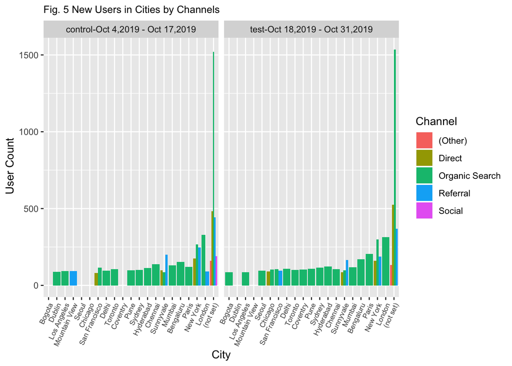

```r
DC_03  %>%
  group_by( City, Channel, test_categ) %>% filter(New_Users > 80) %>%
  ggplot(aes(reorder(x = as.factor(City), New_Users ), y = New_Users, fill = Channel )) + geom_bar(stat = 'identity' , position = "dodge") + ggtitle("Fig. 5 New Users in Cities by Channels ")  + theme(plot.title = element_text(size =10),axis.text.x = element_text(size =7,angle = 65, hjust = 1) )  +  xlab("City") + ylab(" User Count") + facet_wrap(~test_categ)
```

Import Data Channel-New Users - Country

```r
DCo <-  read_excel("~/Desktop/Job related/Surefoot/Surefoot 2/Surefoot- GA/Analysis - 2/test and control dates/New Users + Channel/Channel+country.xlsx", sheet = 2)
```

Data wrangling

```r
DC_01 <- DCo

colnames(DC_01)[colnames(DC_01)=="Default Channel Grouping"] <- "Channel"
colnames(DC_01)[colnames(DC_01)=="Date Range"] <- "Date_Range"
colnames(DC_01)[colnames(DC_01)=="New Users"] <- "New_Users"
colnames(DC_01)[colnames(DC_01)=="Bounce Rate"] <- "Bounce_Rate"


DC_02 <- DC_01 %>% filter(!is.na(Channel))

DC_03 <- DC_02 %>% mutate(test_categ = ifelse(Date_Range == "Oct 18, 2019 - Oct 31, 2019", "test-Oct 18,2019 - Oct 31,2019", "control-Oct 4,2019 - Oct 17,2019"))

DCo_m <- DC_03 %>% filter(Date_Range == "Oct 18, 2019 - Oct 31, 2019")
```

Channel-New Users- country

```r
library(scales)
```

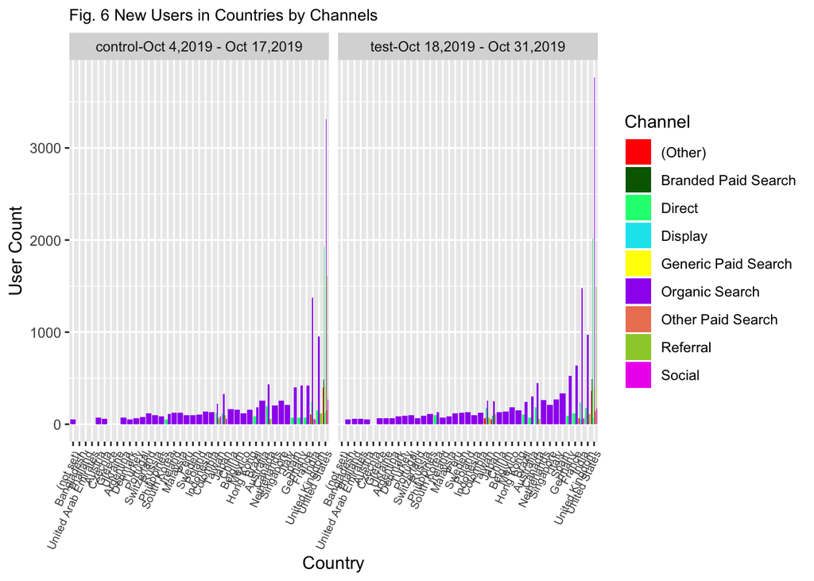

```r
DC_03  %>%
  group_by( Country, Channel, test_categ) %>% filter(New_Users > 50) %>%
  ggplot(aes(reorder(x = as.factor(Country), New_Users  ), y = New_Users, fill = Channel )) + geom_bar(stat = 'identity' , position = "dodge") + ggtitle("Fig. 6 New Users in Countries by Channels ")  + theme(plot.title = element_text(size =10),axis.text.x = element_text(size =7,angle = 65, hjust = 1) )  +  xlab("Country") + ylab("User Count")  +  scale_fill_manual(values=c("red", "darkgreen", "springgreen1", "turquoise2", "yellow",  "purple", "salmon2", "olivedrab3", "magenta2", "khaki3", "brown2", "maroon2", "coral1", "grey45", "goldenrod1", "slategray3","tan4", "orchid3", "hotpink4", "black", "brown4", "lightpink2" )) + guides(colour = guide_legend(override.aes = list(size=3, alpha = 1))) + scale_shape_manual(values=c(3:9)) + facet_wrap(~test_categ)
```

Import Data Channel-New Users - Hour

```r
DH <-  read_excel("~/Desktop/Job related/Surefoot/Surefoot 2/Surefoot- GA/Analysis - 2/test and control dates/New Users + Channel/Channel+Hour.xlsx", sheet = 2)
```

Data wrangling

```r
DC_01 <- DH

colnames(DC_01)[colnames(DC_01)=="Default Channel Grouping"] <- "Channel"
colnames(DC_01)[colnames(DC_01)=="Date Range"] <- "Date_Range"
colnames(DC_01)[colnames(DC_01)=="New Users"] <- "New_Users"
colnames(DC_01)[colnames(DC_01)=="Bounce Rate"] <- "Bounce_Rate"


DC_02 <- DC_01 %>% filter(!is.na(Channel))

DC_03 <- DC_02 %>% mutate(test_categ = ifelse(Date_Range == "Oct 18, 2019 - Oct 31, 2019", "test-Oct 18,2019 - Oct 31,2019", "control-Oct 4,2019 - Oct 17,2019"))

DH_m  <- DC_03 %>% filter(Date_Range == "Oct 18, 2019 - Oct 31, 2019")
```

Channel-New Users- Hour

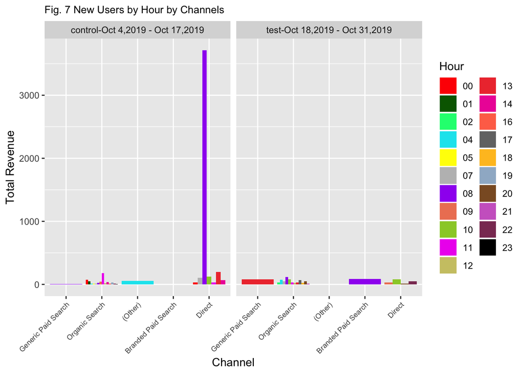

```r
DC_04 <- DC_03 %>% select(Channel,  Hour, Revenue, test_categ)
DC_05 <- unique(DC_04)

DC_06 <- DC_05 %>% group_by(Channel, Hour, test_categ) %>% mutate(TotRev = sum(Revenue)) %>% select(Channel, Hour, TotRev, test_categ)
DC_07 <- unique(DC_06)


DC_07$Hour<- as.factor(DC_07$Hour)
DC_07  %>% filter(TotRev > 0) %>%
ggplot(aes(reorder(x=Channel, TotRev), y=TotRev, fill=Hour)) +
  geom_bar(stat="identity", position = "dodge")  + theme(plot.title = element_text(size =10),axis.text.x = element_text(size =7,angle = 45, hjust = 1) ) + ggtitle("Fig. 7 New Users by Hour by Channels ") +xlab("Channel") + ylab("Total Revenue") +  scale_fill_manual(values=c("red", "darkgreen", "springgreen1", "turquoise2", "yellow", "grey", "purple", "salmon2", "olivedrab3", "magenta2", "khaki3", "brown2", "maroon2", "coral1", "grey45", "goldenrod1", "slategray3","tan4", "orchid3", "hotpink4", "black", "brown4", "lightpink2" )) + guides(colour = guide_legend(override.aes = list(size=3, alpha = 1))) + scale_shape_manual(values=c(3:9)) + facet_wrap(~test_categ)
```

Import Data Channel-New Users - Age

```r
DAge <-  read_excel("~/Desktop/Job related/Surefoot/Surefoot 2/Surefoot- GA/Analysis - 2/test and control dates/New Users + Channel/Channel+Age.xlsx", sheet = 2)
```

Data wrangling

```r
DC_01 <- DAge

colnames(DC_01)[colnames(DC_01)=="Default Channel Grouping"] <- "Channel"
colnames(DC_01)[colnames(DC_01)=="Date Range"] <- "Date_Range"
colnames(DC_01)[colnames(DC_01)=="New Users"] <- "New_Users"
colnames(DC_01)[colnames(DC_01)=="Bounce Rate"] <- "Bounce_Rate"


DC_02 <- DC_01 %>% filter(!is.na(Channel))

DC_03 <- DC_02 %>% mutate(test_categ = ifelse(Date_Range == "Oct 18, 2019 - Oct 31, 2019", "test-Oct 18,2019 - Oct 31,2019", "control-Oct 4,2019 - Oct 17,2019"))

DAge_m  <- DC_03 %>% filter(Date_Range == "Oct 18, 2019 - Oct 31, 2019")
```

Channel-New Users- Age

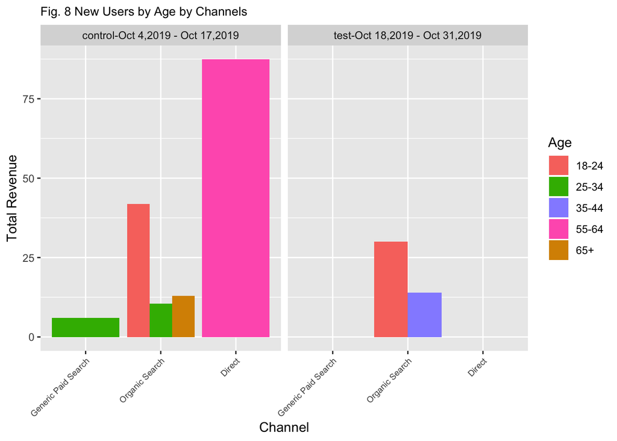

```r
DA_20 <- DC_03 %>% select( Age, Channel, Revenue, test_categ)
DA_21 <- unique(DA_20)



DA_24 <- DA_21 %>% select(Age, Channel, Revenue, test_categ) %>% group_by(Channel, Age, test_categ) %>% mutate(  TotRev = sum(Revenue)) %>% select(Channel, Age, TotRev, test_categ)
DA_25 <- unique(DA_24)


DA_25$Age<- as.factor(DA_25$Age)
DA_25 %>%   filter(TotRev > 0) %>%
ggplot(aes(reorder(x=Channel, TotRev), y=TotRev, fill=Age)) +
  geom_bar(stat="identity", position = "dodge")  + theme(plot.title = element_text(size =10),axis.text.x = element_text(size =7,angle = 45, hjust = 1) ) + ggtitle("Fig. 8 New Users by Age by Channels ")+xlab("Channel") + ylab("Total Revenue") +  scale_fill_manual(values=c("#F8766D", "#39B600",  "#9590FF", "#FF62BC", "#D89000", "#00C1A3", "#A3A500", "#EA8331", "#00BFCD", "#00B4F0", "#00BFC4" )) + guides(colour = guide_legend(override.aes = list(size=3, alpha = 1))) + scale_shape_manual(values=c(3:9)) + facet_wrap(~test_categ)
```

Import Data Channel-New Users - Gender

```r
DG <-  read_excel("~/Desktop/Job related/Surefoot/Surefoot 2/Surefoot- GA/Analysis - 2/test and control dates/New Users + Channel/Channel+Gender.xlsx", sheet = 2)
```

Data wrangling

```r
DC_01 <- DG

colnames(DC_01)[colnames(DC_01)=="Default Channel Grouping"] <- "Channel"
colnames(DC_01)[colnames(DC_01)=="Date Range"] <- "Date_Range"
colnames(DC_01)[colnames(DC_01)=="New Users"] <- "New_Users"
colnames(DC_01)[colnames(DC_01)=="Bounce Rate"] <- "Bounce_Rate"


DC_02 <- DC_01 %>% filter(!is.na(Channel))

DC_03 <- DC_02 %>% mutate(test_categ = ifelse(Date_Range == "Oct 18, 2019 - Oct 31, 2019", "test-Oct 18,2019 - Oct 31,2019", "control-Oct 4,2019 - Oct 17,2019"))

DG_m  <- DC_03 %>% filter(Date_Range == "Oct 18, 2019 - Oct 31, 2019")
```

Channel-New Users - Gender

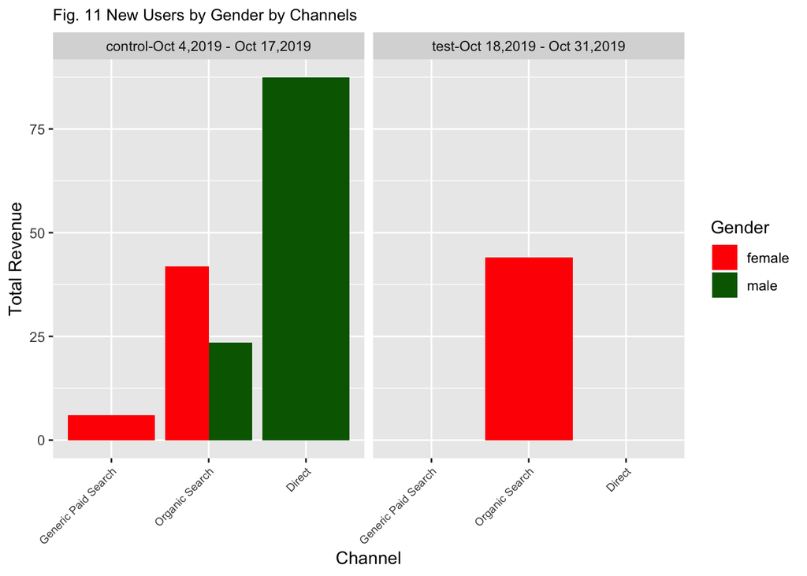

```r
DA_20 <- DC_03 %>% select(Channel, Gender, Revenue, test_categ)
DA_23 <- unique(DA_20)

DA_24 <- DA_23 %>% group_by(Channel, Gender, test_categ) %>% mutate(TotRev = sum(Revenue)) %>% select(Channel, Gender, TotRev, test_categ)
DA_25 <- unique(DA_24)

DA_25$Gender<- as.factor(DA_25$Gender)
DA_25 %>%  filter(TotRev >0) %>%
ggplot(aes(reorder(x=Channel, TotRev), y=TotRev, fill=Gender)) +
  geom_bar(stat="identity", position = "dodge")  + theme(plot.title = element_text(size =10),axis.text.x = element_text(size =7,angle = 45, hjust = 1) ) + ggtitle("Fig. 11 New Users by Gender by Channels ") +xlab("Channel") + ylab("Total Revenue") +   scale_fill_manual(values=c("red", "darkgreen", "springgreen1", "turquoise2", "yellow", "grey", "purple", "salmon2", "olivedrab3", "magenta2", "khaki3", "brown2", "maroon2", "coral1", "grey45", "goldenrod1", "slategray3","tan4", "orchid3", "hotpink4", "black", "brown4", "lightpink2" )) + guides(colour = guide_legend(override.aes = list(size=3, alpha = 1))) + scale_shape_manual(values=c(3:9))  + facet_wrap(~test_categ)
```

Import Data Channel-New Users - Device

```r
DD <-  read_excel("~/Desktop/Job related/Surefoot/Surefoot 2/Surefoot- GA/Analysis - 2/test and control dates/New Users + Channel/Channel+device.xlsx", sheet = 2)
```

Data wrangling

```r
DC_01 <- DD
 names(DD)
```

```
##  [1] "Default Channel Grouping"  "Device Category"
##  [3] "Date Range"                "Segment"
##  [5] "Users"                     "New Users"
##  [7] "Sessions"                  "Bounce Rate"
##  [9] "Pages / Session"           "Avg. Session Duration"
## [11] "Ecommerce Conversion Rate" "Transactions"
## [13] "Revenue"
```

```r
colnames(DC_01)[colnames(DC_01)=="Default Channel Grouping"] <- "Channel"
colnames(DC_01)[colnames(DC_01)=="Device Category"] <- "Device"
colnames(DC_01)[colnames(DC_01)=="Date Range"] <- "Date_Range"
colnames(DC_01)[colnames(DC_01)=="New Users"] <- "New_Users"
colnames(DC_01)[colnames(DC_01)=="Bounce Rate"] <- "Bounce_Rate"


DC_02 <- DC_01 %>% filter(!is.na(Channel))

DC_03 <- DC_02 %>% mutate(test_categ = ifelse(Date_Range == "Oct 18, 2019 - Oct 31, 2019", "test-Oct 18,2019 - Oct 31,2019", "control-Oct 4,2019 - Oct 17,2019"))

DD_m <- DC_03 %>% filter(Date_Range == "Oct 18, 2019 - Oct 31, 2019")
```

Visualization

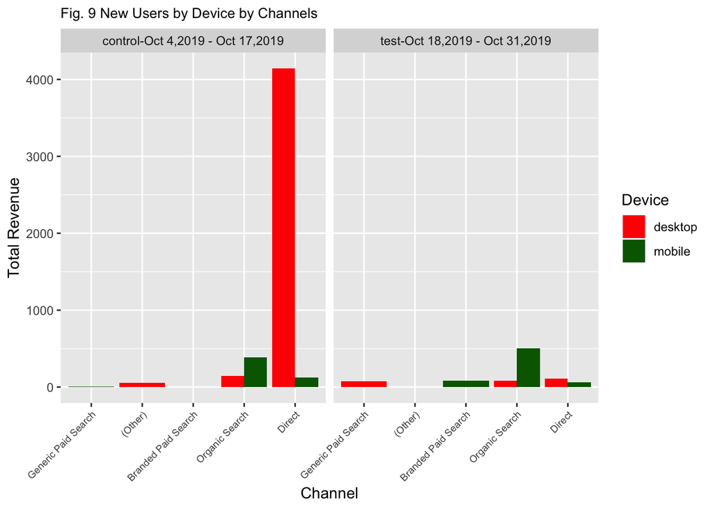

```r
DA_20 <- DC_03  %>% select(Channel, Device, Revenue, test_categ)
DA_23 <- unique(DA_20)

DA_24 <- DA_23 %>% group_by(Channel, Device, test_categ) %>% mutate(TotRev = sum(Revenue)) %>% select(Channel, Device, TotRev, test_categ)
DA_25 <- unique(DA_24)

DA_25$Device<- as.factor(DA_25$Device)
DA_25 %>% filter(TotRev > 0) %>%
ggplot(aes(reorder(x=Channel, TotRev), y=TotRev, fill=Device)) +
  geom_bar(stat="identity", position = "dodge")  + theme(plot.title = element_text(size =10),axis.text.x = element_text(size =7,angle = 45, hjust = 1) ) + ggtitle("Fig. 9 New Users by Device by Channels ") +xlab("Channel") + ylab("Total Revenue") +   scale_fill_manual(values=c("red", "darkgreen", "springgreen1", "turquoise2", "yellow", "grey", "purple", "salmon2", "olivedrab3", "magenta2", "khaki3", "brown2", "maroon2", "coral1", "grey45", "goldenrod1", "slategray3","tan4", "orchid3", "hotpink4", "black", "brown4", "lightpink2" )) + guides(colour = guide_legend(override.aes = list(size=3, alpha = 1))) + scale_shape_manual(values=c(3:9)) + facet_wrap(~test_categ)
```

Import Data Channel-New Users - Behaviour(Page Views)

```r
DP <-  read_excel("~/Desktop/Job related/Surefoot/Surefoot 2/Surefoot- GA/Analysis - 2/test and control dates/New Users + Channel/Channel+Page.xlsx", sheet = 2)
```

Data wrangling

```r
DC_01 <- DP
colnames(DC_01)[colnames(DC_01)=="Default Channel Grouping"] <- "Channel"
colnames(DC_01)[colnames(DC_01)=="Date Range"] <- "Date_Range"
colnames(DC_01)[colnames(DC_01)=="New Users"] <- "New_Users"
colnames(DC_01)[colnames(DC_01)=="Bounce Rate"] <- "Bounce_Rate"


DC_02 <- DC_01 %>% filter(!is.na(Channel))

DC_03 <- DC_02 %>% mutate(test_categ = ifelse(Date_Range == "Oct 18, 2019 - Oct 31, 2019", "test-Oct 18,2019 - Oct 31,2019", "control-Oct 4,2019 - Oct 17,2019"))

DP_m  <- DC_03 %>% filter(Date_Range == "Oct 18, 2019 - Oct 31, 2019")
```

Visualization

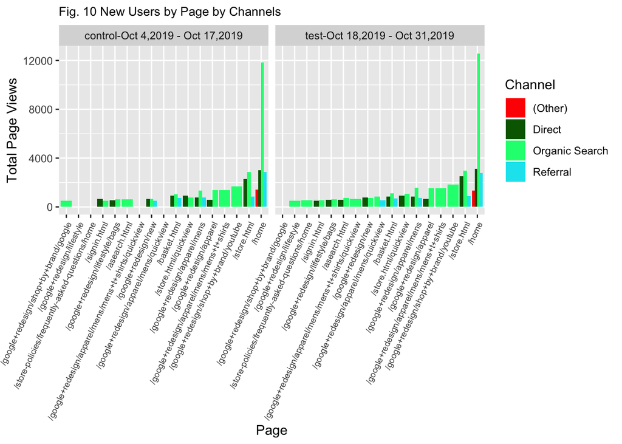

```r
DA_20 <- DC_03  %>% select(Channel, Page, Pageviews, test_categ)
DA_23 <- unique(DA_20)

DA_24 <- DA_23 %>% group_by(Channel, Page, test_categ) %>% mutate(TotPV = sum(Pageviews)) %>% select(Channel, Page, TotPV, test_categ)
DA_25 <- unique(DA_24)

DA_25$Channel<- as.factor(DA_25$Channel)
DA_25 %>% filter(TotPV > 500) %>%
ggplot(aes(reorder(x=Page, TotPV), y=TotPV, fill=Channel)) +
  geom_bar(stat="identity", position = "dodge")  + theme(plot.title = element_text(size =10),axis.text.x = element_text(size =7,angle = 65, hjust = 1) ) + ggtitle("Fig. 10 New Users by Page by Channels ") +xlab("Page") + ylab("Total Page Views") +   scale_fill_manual(values=c("red", "darkgreen", "springgreen1", "turquoise2", "yellow", "grey", "purple", "salmon2", "olivedrab3", "magenta2", "khaki3", "brown2", "maroon2", "coral1", "grey45", "goldenrod1", "slategray3","tan4", "orchid3", "hotpink4", "black", "brown4", "lightpink2" )) + guides(colour = guide_legend(override.aes = list(size=3, alpha = 1))) + scale_shape_manual(values=c(3:9)) + facet_wrap(~test_categ)
```

Import Data Channel-New Users - Source

```r
DS <-  read_excel("~/Desktop/Job related/Surefoot/Surefoot 2/Surefoot- GA/Analysis - 2/test and control dates/New Users + Channel/Channel+Source.xlsx", sheet = 2)
```

Data wrangling

```r
DC_01 <- DS
colnames(DC_01)[colnames(DC_01)=="Default Channel Grouping"] <- "Channel"
colnames(DC_01)[colnames(DC_01)=="Date Range"] <- "Date_Range"
colnames(DC_01)[colnames(DC_01)=="New Users"] <- "New_Users"
colnames(DC_01)[colnames(DC_01)=="Bounce Rate"] <- "Bounce_Rate"


DC_02 <- DC_01 %>% filter(!is.na(Channel))

DC_03 <- DC_02 %>% mutate(test_categ = ifelse(Date_Range == "Oct 18, 2019 - Oct 31, 2019", "test-Oct 18,2019 - Oct 31,2019", "control-Oct 4,2019 - Oct 17,2019"))

DS_m  <- DC_03 %>% filter(Date_Range == "Oct 18, 2019 - Oct 31, 2019")
```

Visualization

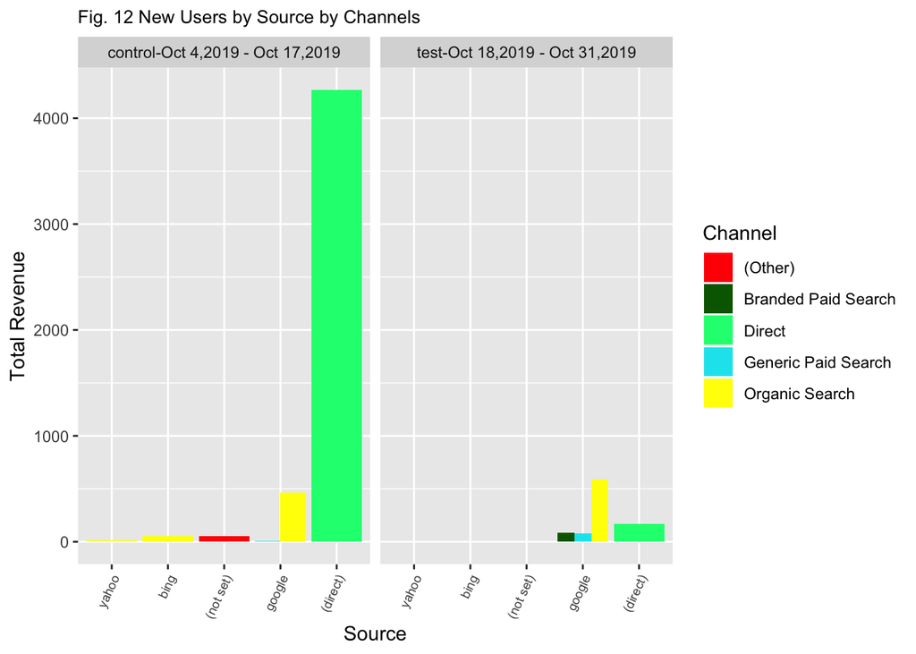

```r
DA_20 <- DC_03  %>% select(Channel, Source, Revenue, test_categ)
DA_23 <- unique(DA_20)

DA_24 <- DA_23 %>% group_by(Channel, Source, test_categ) %>% mutate(TotRv = sum(Revenue)) %>% select(Channel, Source, TotRv, test_categ)
DA_25 <- unique(DA_24)

DA_25$Channel<- as.factor(DA_25$Channel)
DA_25 %>%  filter(TotRv > 0 ) %>%
ggplot(aes(reorder(x=Source, TotRv), y=TotRv, fill=Channel)) +
  geom_bar(stat="identity", position = "dodge")  + theme(plot.title = element_text(size =10),axis.text.x = element_text(size =7,angle = 65, hjust = 1) ) + ggtitle("Fig. 12 New Users by Source by Channels ") +xlab("Source") + ylab("Total Revenue") +   scale_fill_manual(values=c("red", "darkgreen", "springgreen1", "turquoise2", "yellow", "grey", "purple", "salmon2", "olivedrab3", "magenta2", "khaki3", "brown2", "maroon2", "coral1", "grey45", "goldenrod1", "slategray3","tan4", "orchid3", "hotpink4", "black", "brown4", "lightpink2" )) + guides(colour = guide_legend(override.aes = list(size=3, alpha = 1))) + scale_shape_manual(values=c(3:9)) + facet_wrap(~test_categ)
```

Import Data Channel-New Users - Ad content

```r
DAd <-  read_excel("~/Desktop/Job related/Surefoot/Surefoot 2/Surefoot- GA/Analysis - 2/test and control dates/New Users + Channel/Channel+Adcontent.xlsx", sheet = 2)
```

Data wrangling

```r
DC_01 <- DAd

colnames(DC_01)[colnames(DC_01)=="Ad Content"] <- "Ad_Content"
colnames(DC_01)[colnames(DC_01)=="Default Channel Grouping"] <- "Channel"
colnames(DC_01)[colnames(DC_01)=="Date Range"] <- "Date_Range"
colnames(DC_01)[colnames(DC_01)=="New Users"] <- "New_Users"
colnames(DC_01)[colnames(DC_01)=="Bounce Rate"] <- "Bounce_Rate"


DC_02 <- DC_01 %>% filter(!is.na(Channel))

DC_03 <- DC_02 %>% mutate(test_categ = ifelse(Date_Range == "Oct 18, 2019 - Oct 31, 2019", "test-Oct 18,2019 - Oct 31,2019", "control-Oct 4,2019 - Oct 17,2019"))

DAd_m  <- DC_03 %>% filter(Date_Range == "Oct 18, 2019 - Oct 31, 2019")
```

Visualization

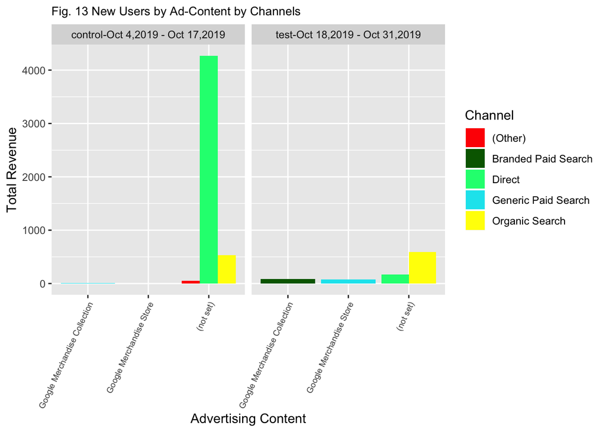

```r
DA_20 <- DC_03  %>% select(Channel, Ad_Content , Revenue, test_categ)
DA_23 <- unique(DA_20)

DA_24 <- DA_23 %>% group_by(Channel, Ad_Content, test_categ) %>% mutate(TotRv = sum(Revenue)) %>% select(Channel, Ad_Content, TotRv, test_categ)
DA_25 <- unique(DA_24)

DA_25$Channel<- as.factor(DA_25$Channel)
DA_25 %>%  filter(TotRv > 0 ) %>%
ggplot(aes(reorder(x=Ad_Content, TotRv), y=TotRv, fill=Channel)) +
  geom_bar(stat="identity", position = "dodge")  + theme(plot.title = element_text(size =10),axis.text.x = element_text(size =7,angle = 65, hjust = 1) ) + ggtitle("Fig. 13 New Users by Ad-Content by Channels ") +xlab("Advertising Content") + ylab("Total Revenue") +   scale_fill_manual(values=c("red", "darkgreen", "springgreen1", "turquoise2", "yellow", "grey", "purple", "salmon2", "olivedrab3", "magenta2", "khaki3", "brown2", "maroon2", "coral1", "grey45", "goldenrod1", "slategray3","tan4", "orchid3", "hotpink4", "black", "brown4", "lightpink2" )) + guides(colour = guide_legend(override.aes = list(size=3, alpha = 1))) + scale_shape_manual(values=c(3:9)) + facet_wrap(~test_categ)
```

Import Data Channel-New Users - Goal1 - Purchases Completed

```r
DA_Goal1 <-  read_excel("~/Desktop/Job related/Surefoot/Surefoot 2/Surefoot- GA/Analysis - 2/test and control dates/New Users + Channel/Channel+Goal1.xlsx", sheet = 2)
```

Data wrangling

```r
DC_01 <- DA_Goal1

colnames(DC_01)[colnames(DC_01)=="Purchase Completed (Goal 1 Completions)"] <- "Purchases_completed"
colnames(DC_01)[colnames(DC_01)=="Default Channel Grouping"] <- "Channel"
colnames(DC_01)[colnames(DC_01)=="Date Range"] <- "Date_Range"
colnames(DC_01)[colnames(DC_01)=="New Users"] <- "New_Users"
colnames(DC_01)[colnames(DC_01)=="Bounce Rate"] <- "Bounce_Rate"


DC_02 <- DC_01 %>% filter(!is.na(Channel))

DC_03 <- DC_02 %>% mutate(test_categ = ifelse(Date_Range == "Oct 18, 2019 - Oct 31, 2019", "test-Oct 18,2019 - Oct 31,2019", "control-Oct 4,2019 - Oct 17,2019"))

DG1_m  <- DC_03 %>% filter(Date_Range == "Oct 18, 2019 - Oct 31, 2019")
```

Visualizations

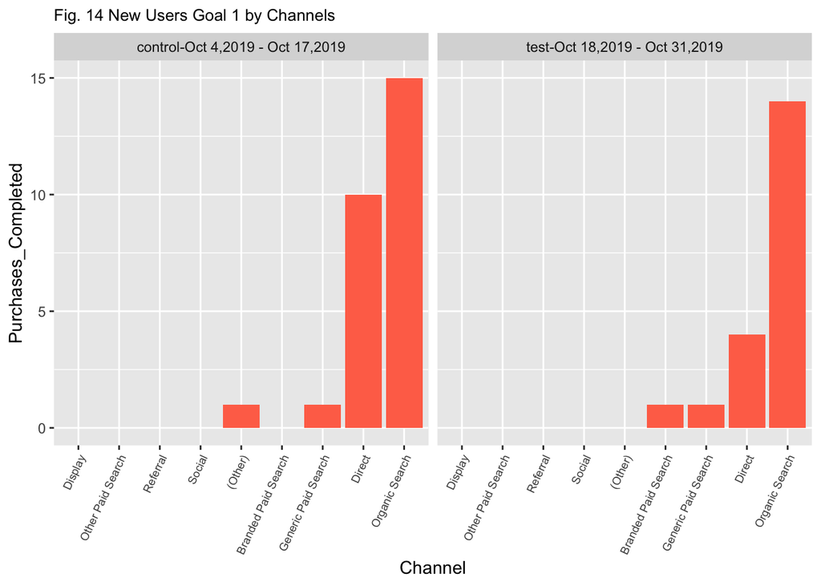

```r
DC_03 %>%
ggplot(aes(reorder(x=Channel, Purchases_completed), y=Purchases_completed )) +
  geom_bar(stat="identity",fill = "coral1")  + theme(plot.title = element_text(size =10),axis.text.x = element_text(size =7,angle = 65, hjust = 1) ) + ggtitle("Fig. 14 New Users Goal 1 by Channels ") +xlab("Channel") + ylab("Purchases_Completed")  + facet_wrap(~test_categ)
```

Import Data Channel-New Users - Goal2 - Engaged Users

```r
DA_Goal2 <-  read_excel("~/Desktop/Job related/Surefoot/Surefoot 2/Surefoot- GA/Analysis - 2/test and control dates/New Users + Channel/Channel+Goal2.xlsx", sheet = 2)
```

Data wrangling

```r
DC_01 <- DA_Goal2

colnames(DC_01)[colnames(DC_01)=="Engaged Users (Goal 2 Completions)"] <- "Engaged_Users"
colnames(DC_01)[colnames(DC_01)=="Default Channel Grouping"] <- "Channel"
colnames(DC_01)[colnames(DC_01)=="Date Range"] <- "Date_Range"
colnames(DC_01)[colnames(DC_01)=="New Users"] <- "New_Users"
colnames(DC_01)[colnames(DC_01)=="Bounce Rate"] <- "Bounce_Rate"


DC_02 <- DC_01 %>% filter(!is.na(Channel))

DC_03 <- DC_02 %>% mutate(test_categ = ifelse(Date_Range == "Oct 18, 2019 - Oct 31, 2019", "test-Oct 18,2019 - Oct 31,2019", "control-Oct 4,2019 - Oct 17,2019"))

DG2_m  <- DC_03 %>% filter(Date_Range == "Oct 18, 2019 - Oct 31, 2019")
```

Visualizations

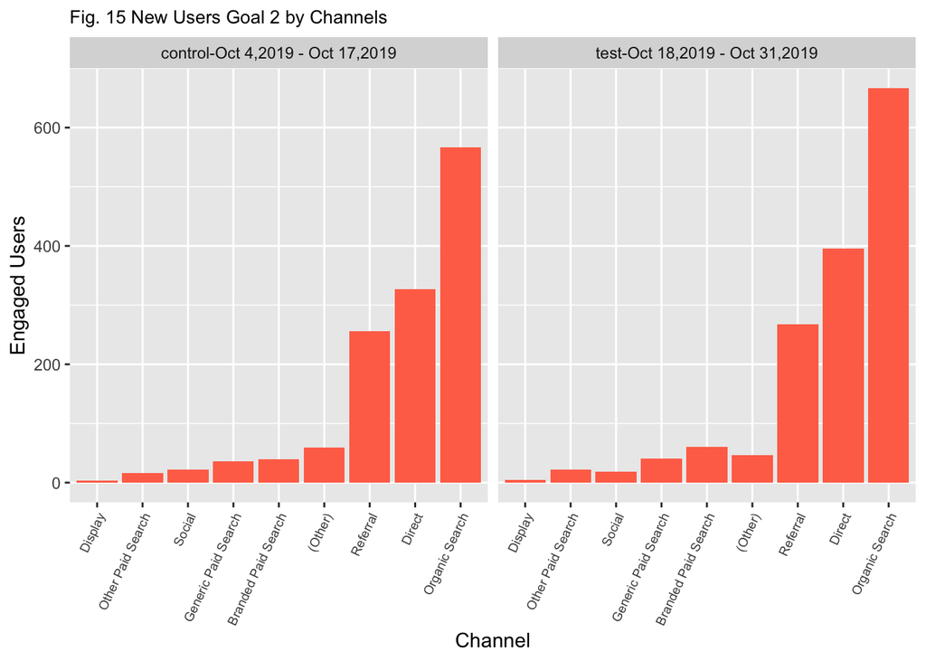

```r
DC_03 %>%
ggplot(aes(reorder(x=Channel, Engaged_Users), y=Engaged_Users )) +
  geom_bar(stat="identity",fill = "coral1")  + theme(plot.title = element_text(size =10),axis.text.x = element_text(size =7,angle = 65, hjust = 1) ) + ggtitle("Fig. 15 New Users Goal 2 by Channels ") +xlab("Channel") + ylab("Engaged Users") +  facet_wrap(~test_categ)
```

Import Data Channel-New Users - Goal3 - Registrations Completed

```r
DA_Goal3 <-  read_excel("~/Desktop/Job related/Surefoot/Surefoot 2/Surefoot- GA/Analysis - 2/test and control dates/New Users + Channel/Channel+Goal3.xlsx", sheet = 2)
```

Data wrangling

```r
DC_01 <- DA_Goal3

colnames(DC_01)[colnames(DC_01)=="Registrations (Goal 3 Completions)"] <- "Registrations_completed"
colnames(DC_01)[colnames(DC_01)=="Default Channel Grouping"] <- "Channel"
colnames(DC_01)[colnames(DC_01)=="Date Range"] <- "Date_Range"
colnames(DC_01)[colnames(DC_01)=="New Users"] <- "New_Users"
colnames(DC_01)[colnames(DC_01)=="Bounce Rate"] <- "Bounce_Rate"


DC_02 <- DC_01 %>% filter(!is.na(Channel))

DC_03 <- DC_02 %>% mutate(test_categ = ifelse(Date_Range == "Oct 18, 2019 - Oct 31, 2019", "test-Oct 18,2019 - Oct 31,2019", "control-Oct 4,2019 - Oct 17,2019"))

DG3_m  <- DC_03 %>% filter(Date_Range == "Oct 18, 2019 - Oct 31, 2019")
```

Visualizations

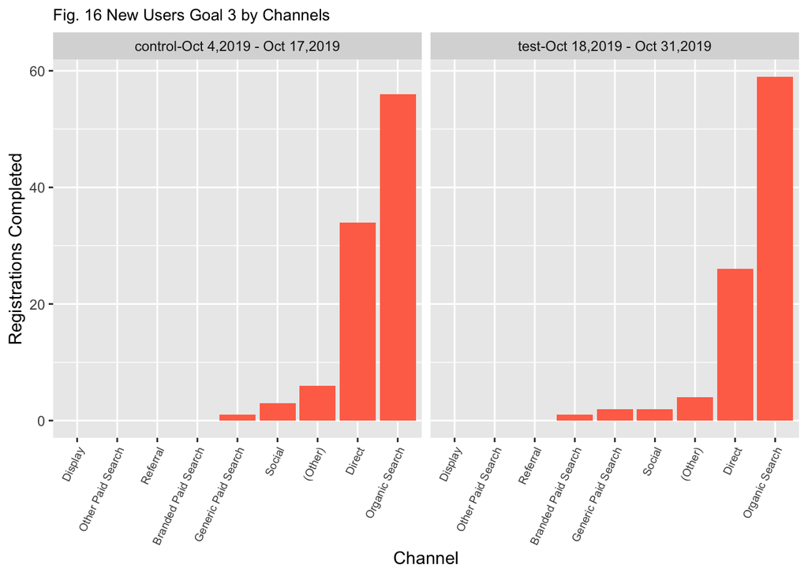

```r
DC_03 %>%
ggplot(aes(reorder(x=Channel, Registrations_completed), y=Registrations_completed)) +
  geom_bar(stat="identity",fill = "coral1")  + theme(plot.title = element_text(size =10),axis.text.x = element_text(size =7,angle = 65, hjust = 1) ) + ggtitle("Fig. 16 New Users Goal 3 by Channels ") +xlab("Channel") + ylab("Registrations Completed") +  facet_wrap(~test_categ)
```

Import Data Channel-New Users - Goal4 - Entered Checkout

```r
DA_Goal4 <-  read_excel("~/Desktop/Job related/Surefoot/Surefoot 2/Surefoot- GA/Analysis - 2/test and control dates/New Users + Channel/Channel+Goal4.xlsx", sheet = 2)
```

Data wrangling

```r
DC_01 <- DA_Goal4

colnames(DC_01)[colnames(DC_01)=="Entered Checkout (Goal 4 Completions)"] <- "Entered_checkout"
colnames(DC_01)[colnames(DC_01)=="Default Channel Grouping"] <- "Channel"
colnames(DC_01)[colnames(DC_01)=="Date Range"] <- "Date_Range"
colnames(DC_01)[colnames(DC_01)=="New Users"] <- "New_Users"
colnames(DC_01)[colnames(DC_01)=="Bounce Rate"] <- "Bounce_Rate"


DC_02 <- DC_01 %>% filter(!is.na(Channel))

DC_03 <- DC_02 %>% mutate(test_categ = ifelse(Date_Range == "Oct 18, 2019 - Oct 31, 2019", "test-Oct 18,2019 - Oct 31,2019", "control-Oct 4,2019 - Oct 17,2019"))

DG4_m  <- DC_03 %>% filter(Date_Range == "Oct 18, 2019 - Oct 31, 2019")
```

Visualizations

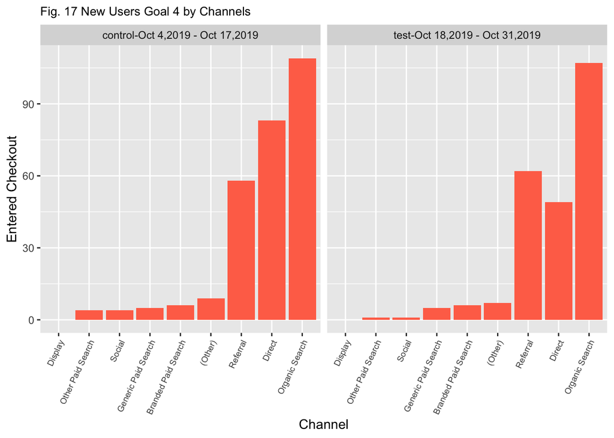

```r
DC_03 %>%
ggplot(aes(reorder(x=Channel, Entered_checkout), y=Entered_checkout)) +
  geom_bar(stat="identity",fill = "coral1")  + theme(plot.title = element_text(size =10),axis.text.x = element_text(size =7,angle = 65, hjust = 1) ) + ggtitle("Fig. 17 New Users Goal 4 by Channels ") +xlab("Channel") + ylab("Entered Checkout") + facet_wrap(~test_categ)
```

Import Data Channel-New Users - Goal5 - Smart Goals

```r
DA_Goal5 <-  read_excel("~/Desktop/Job related/Surefoot/Surefoot 2/Surefoot- GA/Analysis - 2/test and control dates/New Users + Channel/Channel+Goal5.xlsx", sheet = 2)
```

Data wrangling

```r
DC_01 <- DA_Goal5

colnames(DC_01)[colnames(DC_01)=="Smart Goals (Goal 5 Completions)"] <- "Smart_Goals"
colnames(DC_01)[colnames(DC_01)=="Default Channel Grouping"] <- "Channel"
colnames(DC_01)[colnames(DC_01)=="Date Range"] <- "Date_Range"
colnames(DC_01)[colnames(DC_01)=="New Users"] <- "New_Users"
colnames(DC_01)[colnames(DC_01)=="Bounce Rate"] <- "Bounce_Rate"


DC_02 <- DC_01 %>% filter(!is.na(Channel))

DC_03 <- DC_02 %>% mutate(test_categ = ifelse(Date_Range == "Oct 18, 2019 - Oct 31, 2019", "test-Oct 18,2019 - Oct 31,2019", "control-Oct 4,2019 - Oct 17,2019"))

DG5_m  <- DC_03 %>% filter(Date_Range == "Oct 18, 2019 - Oct 31, 2019")
```

Visualizations

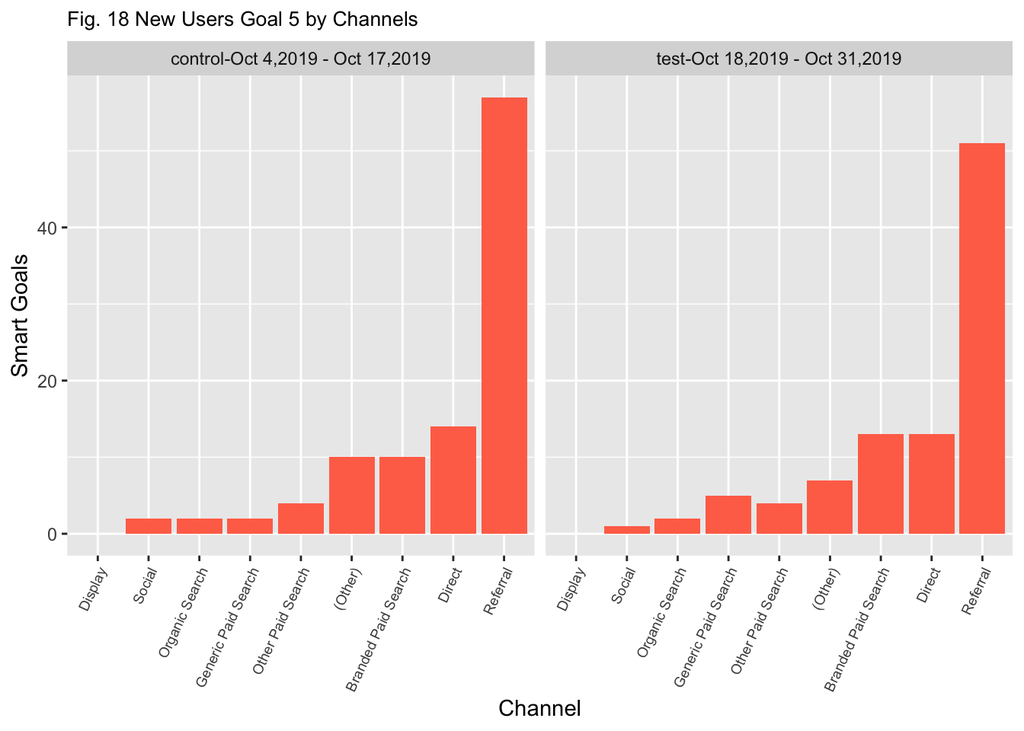

```r
DC_03 %>%
ggplot(aes(reorder(x=Channel, Smart_Goals), y=Smart_Goals)) +
  geom_bar(stat="identity",fill = "coral1")  + theme(plot.title = element_text(size =10),axis.text.x = element_text(size =7,angle = 65, hjust = 1) ) + ggtitle("Fig. 18 New Users Goal 5 by Channels ") +xlab("Channel") + ylab("Smart Goals") +  facet_wrap(~test_categ)
```

Linear Regression

```r
colnames(DAge_m)[colnames(DAge_m)=="Pages / Session"] <- "Page_Session"
colnames(DAge_m)[colnames(DAge_m)=="Avg. Session Duration"] <- "Avg_Session_Duration"
colnames(DAge_m)[colnames(DAge_m)=="Ecommerce Conversion Rate"] <- "E_Conversion_Rate"

colnames(DG_m)[colnames(DG_m)=="Pages / Session"] <- "Page_Session"
colnames(DG_m)[colnames(DG_m)=="Avg. Session Duration"] <- "Avg_Session_Duration"
colnames(DG_m)[colnames(DG_m)=="Ecommerce Conversion Rate"] <- "E_Conversion_Rate"


colnames(DG1_m)[colnames(DG1_m)=="Pages / Session"] <- "Page_Session"
colnames(DG1_m)[colnames(DG1_m)=="Avg. Session Duration"] <- "Avg_Session_Duration"
colnames(DG1_m)[colnames(DG1_m)=="Ecommerce Conversion Rate"] <- "E_Conversion_Rate"

colnames(DG2_m)[colnames(DG2_m)=="Pages / Session"] <- "Page_Session"
colnames(DG2_m)[colnames(DG2_m)=="Avg. Session Duration"] <- "Avg_Session_Duration"
colnames(DG2_m)[colnames(DG2_m)=="Ecommerce Conversion Rate"] <- "E_Conversion_Rate"

model_01x <- lm(Revenue ~ Channel+Age+New_Users+Bounce_Rate+Transactions+Page_Session +E_Conversion_Rate , data = DAge_m)
summary(model_01x)
```

```
##
## Call:
## lm(formula = Revenue ~ Channel + Age + New_Users + Bounce_Rate +
##     Transactions + Page_Session + E_Conversion_Rate, data = DAge_m)
##
## Residuals:
##        Min         1Q     Median         3Q        Max
## -1.026e-14 -2.315e-15  0.000e+00  1.545e-15  1.101e-14
##
## Coefficients:
##                              Estimate Std. Error    t value Pr(>|t|)
## (Intercept)                -1.852e-15  9.994e-15 -1.850e-01 0.854769
## ChannelBranded Paid Search  1.128e-13  3.809e-15  2.963e+01  < 2e-16 ***
## ChannelDirect              -6.364e-14  3.580e-15 -1.778e+01 3.91e-14 ***
## ChannelDisplay              8.805e-15  5.443e-15  1.618e+00 0.120657
## ChannelGeneric Paid Search  6.652e-15  4.203e-15  1.583e+00 0.128397
## ChannelOrganic Search      -2.729e-15  5.122e-15 -5.330e-01 0.599785
## ChannelOther Paid Search   -2.818e-15  4.847e-15 -5.810e-01 0.567206
## ChannelReferral            -3.965e-15  3.953e-15 -1.003e+00 0.327284
## ChannelSocial               1.909e-15  4.007e-15  4.760e-01 0.638755
## Age25-34                   -7.915e-15  2.897e-15 -2.733e+00 0.012476 *
## Age35-44                   -2.652e-15  2.932e-15 -9.040e-01 0.376037
## Age45-54                    9.091e-16  3.400e-15  2.670e-01 0.791801
## Age55-64                   -3.023e-15  3.649e-15 -8.280e-01 0.416789
## Age65+                     -1.247e-15  5.362e-15 -2.330e-01 0.818318
## New_Users                   1.544e-17  3.809e-18  4.053e+00 0.000572 ***
## Bounce_Rate                 1.754e-15  1.355e-14  1.290e-01 0.898272
## Transactions                5.618e+01  1.905e-14  2.949e+15  < 2e-16 ***
## Page_Session                4.649e-16  1.096e-15  4.240e-01 0.675792
## E_Conversion_Rate          -3.590e+04  1.907e-11 -1.882e+15  < 2e-16 ***
## ---
## Signif. codes:  0 '***' 0.001 '**' 0.01 '*' 0.05 '.' 0.1 ' ' 1
##
## Residual standard error: 5.482e-15 on 21 degrees of freedom
## Multiple R-squared:      1,  Adjusted R-squared:      1
## F-statistic: 1.937e+30 on 18 and 21 DF,  p-value: < 2.2e-16
```

```r
model_02x <- lm(Revenue ~ Channel+ Gender +New_Users+Bounce_Rate+Transactions+Page_Session   , data = DG_m)
summary(model_02x)
```

```
##
## Call:
## lm(formula = Revenue ~ Channel + Gender + New_Users + Bounce_Rate +
##     Transactions + Page_Session, data = DG_m)
##
## Residuals:
##          1          2          3          4          5          6
## -1.085e-30 -3.433e-32 -1.147e-15  1.347e-15  1.147e-15 -1.347e-15
##          7          8          9         10         11         12
## -9.243e-16  9.243e-16  1.890e-15  1.807e-15 -2.517e-15 -1.807e-15
##         13         14         15         16         17         18
##  7.627e-16 -1.890e-15  3.075e-16  2.517e-15 -7.627e-16 -3.075e-16
##
## Coefficients:
##                              Estimate Std. Error    t value Pr(>|t|)
## (Intercept)                -4.380e-15  2.388e-14 -1.830e-01   0.8634
## ChannelBranded Paid Search  3.919e-14  4.878e-15  8.034e+00   0.0013 **
## ChannelDirect               5.832e-15  1.119e-14  5.210e-01   0.6298
## ChannelDisplay             -4.013e-15  1.152e-14 -3.480e-01   0.7451
## ChannelGeneric Paid Search -1.362e-15  3.706e-15 -3.670e-01   0.7319
## ChannelOrganic Search       4.148e-14  3.560e-14  1.165e+00   0.3087
## ChannelOther Paid Search   -2.244e-15  6.557e-15 -3.420e-01   0.7494
## ChannelReferral             2.432e-15  1.066e-14  2.280e-01   0.8307
## ChannelSocial              -7.576e-16  5.171e-15 -1.470e-01   0.8906
## Gendermale                 -2.460e-15  4.358e-15 -5.640e-01   0.6026
## New_Users                  -7.391e-18  1.209e-17 -6.120e-01   0.5739
## Bounce_Rate                 6.029e-15  3.690e-14  1.630e-01   0.8781
## Transactions                2.200e+01  8.110e-15  2.713e+15   <2e-16 ***
## Page_Session                7.585e-16  1.909e-15  3.970e-01   0.7114
## ---
## Signif. codes:  0 '***' 0.001 '**' 0.01 '*' 0.05 '.' 0.1 ' ' 1
##
## Residual standard error: 2.986e-15 on 4 degrees of freedom
## Multiple R-squared:      1,  Adjusted R-squared:      1
## F-statistic: 1.577e+31 on 13 and 4 DF,  p-value: < 2.2e-16
```

```r
DD_m_01 <- DD_m %>% filter(Device != "tablet")
model_03x <- lm(Revenue ~ Channel+Device+New_Users +Bounce_Rate+Transactions  , data = DD_m_01)
summary(model_03x)
```

```
##
## Call:
## lm(formula = Revenue ~ Channel + Device + New_Users + Bounce_Rate +
##     Transactions, data = DD_m_01)
##
## Residuals:
##        1        2        3        4        5        6        7        8
##   0.7777  -0.7777  19.0970  -9.7129 -19.0970  -1.8112  -1.1277  -4.1095
##        9       10       11       12       13       14       15       16
##   1.1277  -0.5570   1.8112   4.1095   0.1067   0.5570  -3.5637   9.7129
##       17       18
##  -0.1067   3.5637
##
## Coefficients:
##                              Estimate Std. Error t value Pr(>|t|)
## (Intercept)                 4.641e+00  2.937e+01   0.158  0.88062
## ChannelBranded Paid Search  2.883e+00  1.675e+01   0.172  0.87009
## ChannelDirect              -7.888e+01  2.908e+01  -2.713  0.04215 *
## ChannelDisplay              8.610e+00  2.390e+01   0.360  0.73338
## ChannelGeneric Paid Search  2.594e+00  1.454e+01   0.178  0.86546
## ChannelOrganic Search      -2.765e+02  1.017e+02  -2.720  0.04180 *
## ChannelOther Paid Search    1.134e+00  1.652e+01   0.069  0.94796
## ChannelReferral            -6.143e+00  1.555e+01  -0.395  0.70912
## ChannelSocial               3.917e+00  1.615e+01   0.243  0.81801
## Devicemobile               -1.998e+00  8.477e+00  -0.236  0.82300
## New_Users                   6.726e-03  8.879e-03   0.758  0.48290
## Bounce_Rate                -1.681e+01  5.767e+01  -0.291  0.78241
## Transactions                7.611e+01  6.943e+00  10.963  0.00011 ***
## ---
## Signif. codes:  0 '***' 0.001 '**' 0.01 '*' 0.05 '.' 0.1 ' ' 1
##
## Residual standard error: 14.06 on 5 degrees of freedom
## Multiple R-squared:  0.996,  Adjusted R-squared:  0.9863
## F-statistic: 102.9 on 12 and 5 DF,  p-value: 3.579e-05
```

```r
model_04x <- lm(Revenue ~ Channel+Hour+ New_Users +Bounce_Rate+Transactions   , data = DH_m)
c<- data.frame(summary(model_04x)$coef[summary(model_04x)$coef[,4] <= .05, 4])
colnames(c) <- c("p-value")
c
```

```
##                            p-value
## ChannelOrganic Search 1.857244e-02
## Hour08                7.800971e-03
## New_Users             1.367448e-02
## Transactions          2.991725e-36
```

```r
model_06x <- lm(Revenue ~ Channel+  New_Users +Bounce_Rate+Transactions+City   , data = DC_m)
d<- data.frame(summary(model_06x)$coef[summary(model_06x)$coef[,4] <= .05, 4])
colnames(d) <- c("p-value")
d
```

```
##                        p-value
## New_Users         4.261956e-02
## Transactions      0.000000e+00
## CityCambridge     2.611136e-03
## CityChattanooga   2.596088e-02
## CityFort Collins  1.889871e-05
## CityLaguna Niguel 3.198017e-12
## CityLos Angeles   3.404404e-02
## CityMorton Grove  1.936983e-09
## CityPottstown     3.058206e-12
## CityTracy         2.740560e-03
## CityUnion City    3.011555e-03
```

```r
model_07x <- lm(Revenue ~ Channel+   New_Users+Sessions+Bounce_Rate+Transactions+Country   , data = DCo_m)
e<- data.frame(summary(model_07x)$coef[summary(model_07x)$coef[,4] <= .05, 4])
colnames(e) <- c("p-value")
e
```

```
##                                 p-value
## ChannelBranded Paid Search 6.439190e-08
## ChannelGeneric Paid Search 3.525553e-08
## New_Users                  2.855211e-03
## Transactions               0.000000e+00
## CountryCanada              4.129464e-02
## CountryUnited States       4.479712e-13
```

```r
model_08x <- lm( Pageviews ~    Channel+ Bounce_Rate+Entrances+Page   , data = DP_m)
a<- data.frame(summary(model_08x)$coef[summary(model_08x)$coef[,4] <= .05, 4])
colnames(a) <- c("p-value")
a
```

```
##                                                                                                                                                                                      p-value
## (Intercept)                                                                                                                                                                     4.846221e-07
## ChannelDirect                                                                                                                                                                   4.677770e-06
## ChannelDisplay                                                                                                                                                                  6.791253e-05
## ChannelOrganic Search                                                                                                                                                           5.135770e-10
## ChannelReferral                                                                                                                                                                 1.091951e-03
## Entrances                                                                                                                                                                       0.000000e+00
## Page/asearch.html/quickview                                                                                                                                                     3.524200e-02
## Page/basket.html                                                                                                                                                                2.345055e-03
## Page/google+redesign/accessories                                                                                                                                                3.471810e-03
## Page/google+redesign/accessories/android+iconic+4in+decal                                                                                                                       6.901534e-04
## Page/google+redesign/accessories/android+iconic+sticker+sheet                                                                                                                   4.482488e-04
## Page/google+redesign/accessories/android+large+removable+sticker+sheet                                                                                                          4.221572e-04
## Page/google+redesign/accessories/android+puzzlebot+v2                                                                                                                           4.263115e-04
## Page/google+redesign/accessories/android+super+hero+3d+framed+art                                                                                                               8.234268e-04
## Page/google+redesign/accessories/android+techie+3d+framed+art                                                                                                                   2.906781e-04
## Page/google+redesign/accessories/candy+cane+android+cardboard+sculpture                                                                                                         4.154065e-03
## Page/google+redesign/accessories/electronic+accessories                                                                                                                         1.714536e-03
## Page/google+redesign/accessories/electronic+accessories/quickview                                                                                                               3.411057e-02
## Page/google+redesign/accessories/fun                                                                                                                                            6.854312e-03
## Page/google+redesign/accessories/fun/quickview                                                                                                                                  7.705661e-03
## Page/google+redesign/accessories/google+blue+yoyo                                                                                                                               1.168536e-03
## Page/google+redesign/accessories/google+bot                                                                                                                                     2.605183e-04
## Page/google+redesign/accessories/google+cambridge+campus+lapel+pin                                                                                                              5.023521e-04
## Page/google+redesign/accessories/google+cambridge+campus+sticker                                                                                                                1.040193e-03
## Page/google+redesign/accessories/google+campus+bike                                                                                                                             3.860068e-04
```

[output cut: 389 more lines]

```r
model_10x <- lm( Revenue ~  Ad_Content+New_Users+Sessions+Transactions+ Channel+ Bounce_Rate   , data = DAd_m)
f<- data.frame(summary(model_10x)$coef[summary(model_10x)$coef[,4] <= .05, 4])
colnames(f) <- c("p-value")
f
```

```
##                            p-value
## Transactions          9.281423e-13
## ChannelDirect         1.588235e-05
## ChannelOrganic Search 2.258604e-05
```

```r
model_11x <- lm( Purchases_completed ~  New_Users   , data = DG1_m)
summary(model_11x)
```

```
##
## Call:
## lm(formula = Purchases_completed ~ New_Users, data = DG1_m)
##
## Residuals:
##     Min      1Q  Median      3Q     Max
## -2.1261 -0.1563  0.1988  0.3965  1.0737
##
## Coefficients:
##               Estimate Std. Error t value Pr(>|t|)
## (Intercept) -5.010e-01  4.064e-01  -1.233    0.257
## New_Users    1.060e-03  8.543e-05  12.410 5.07e-06 ***
## ---
## Signif. codes:  0 '***' 0.001 '**' 0.01 '*' 0.05 '.' 0.1 ' ' 1
##
## Residual standard error: 1.026 on 7 degrees of freedom
## Multiple R-squared:  0.9565, Adjusted R-squared:  0.9503
## F-statistic:   154 on 1 and 7 DF,  p-value: 5.072e-06
```

```r
model_12x <- lm( Engaged_Users ~  New_Users   , data = DG2_m)
summary(model_12x)
```

```
##
## Call:
## lm(formula = Engaged_Users ~ New_Users, data = DG2_m)
##
## Residuals:
##     Min      1Q  Median      3Q     Max
## -55.567 -46.782 -22.981  -1.756 137.403
##
## Coefficients:
##              Estimate Std. Error t value Pr(>|t|)
## (Intercept) 37.097526  29.940039   1.239    0.255
## New_Users    0.051524   0.006294   8.187 7.86e-05 ***
## ---
## Signif. codes:  0 '***' 0.001 '**' 0.01 '*' 0.05 '.' 0.1 ' ' 1
##
## Residual standard error: 75.6 on 7 degrees of freedom
## Multiple R-squared:  0.9054, Adjusted R-squared:  0.8919
## F-statistic: 67.02 on 1 and 7 DF,  p-value: 7.864e-05
```

```r
model_13x <- lm( Registrations_completed ~  New_Users   , data = DG3_m)
summary(model_13x)
```

```
##
## Call:
## lm(formula = Registrations_completed ~ New_Users, data = DG3_m)
##
## Residuals:
##      Min       1Q   Median       3Q      Max
## -10.0284   0.0342   0.3955   0.6399   7.6159
##
## Coefficients:
##               Estimate Std. Error t value Pr(>|t|)
## (Intercept) -1.3419312  1.9058199  -0.704    0.504
## New_Users    0.0045885  0.0004006  11.454 8.69e-06 ***
## ---
## Signif. codes:  0 '***' 0.001 '**' 0.01 '*' 0.05 '.' 0.1 ' ' 1
##
## Residual standard error: 4.812 on 7 degrees of freedom
## Multiple R-squared:  0.9493, Adjusted R-squared:  0.9421
## F-statistic: 131.2 on 1 and 7 DF,  p-value: 8.688e-06
```

```r
model_14x <- lm( Entered_checkout ~  New_Users   , data = DG4_m)
summary(model_14x)
```

```
##
## Call:
## lm(formula = Entered_checkout ~ New_Users, data = DG4_m)
##
## Residuals:
##    Min     1Q Median     3Q    Max
## -9.377 -7.615 -5.526 -3.371 36.303
##
## Coefficients:
##             Estimate Std. Error t value Pr(>|t|)
## (Intercept) 5.264679   6.174982   0.853 0.422101
## New_Users   0.008245   0.001298   6.352 0.000384 ***
## ---
## Signif. codes:  0 '***' 0.001 '**' 0.01 '*' 0.05 '.' 0.1 ' ' 1
##
## Residual standard error: 15.59 on 7 degrees of freedom
## Multiple R-squared:  0.8522, Adjusted R-squared:  0.8311
## F-statistic: 40.35 on 1 and 7 DF,  p-value: 0.0003844
```

```r
model_15x <- lm(Smart_Goals ~  New_Users    , data = DG5_m)
summary(model_15x)
```

```
##
## Call:
## lm(formula = Smart_Goals ~ New_Users, data = DG5_m)
##
## Residuals:
##     Min      1Q  Median      3Q     Max
## -10.990  -7.145  -5.974   2.040  40.320
##
## Coefficients:
##               Estimate Std. Error t value Pr(>|t|)
## (Intercept) 11.0307368  6.7059318   1.645    0.144
## New_Users   -0.0001417  0.0014096  -0.101    0.923
##
## Residual standard error: 16.93 on 7 degrees of freedom
## Multiple R-squared:  0.001442,   Adjusted R-squared:  -0.1412
## F-statistic: 0.01011 on 1 and 7 DF,  p-value: 0.9227
```